# Project 2A: Galton Data

Dylan Bordinger

Tuesday, December 07, 2021 @ 09:20 AM

## Setup

### Packages Used

```r
library(tidyverse)
library(ggplot2)
library(DT)
```

### Datasets Used

```r
data_main <- read.csv(file = url("https://raw.githubusercontent.com/STAT-JET-ASU/Datasets/master/Instructor/galtonfamiliesmain.csv"))

glimpse(data_main)
```

```
Rows: 898
Columns: 6
$ FamilyID <fct> 1, 1, 1, 1, 2, 2, 2, 2, 3, 3, 4, 4, 4, 4, 4, 5, 5, 5, 5, 5, 5…
$ Children <int> 4, 4, 4, 4, 4, 4, 4, 4, 2, 2, 5, 5, 5, 5, 5, 6, 6, 6, 6, 6, 6…
$ Father   <dbl> 78.5, 78.5, 78.5, 78.5, 75.5, 75.5, 75.5, 75.5, 75.0, 75.0, 7…
$ Mother   <dbl> 67.0, 67.0, 67.0, 67.0, 66.5, 66.5, 66.5, 66.5, 64.0, 64.0, 6…
$ Child    <fct> Son, Daughter, Daughter, Daughter, Son, Son, Daughter, Daught…
$ Height   <dbl> 73.2, 69.2, 69.0, 69.0, 73.5, 72.5, 65.5, 65.5, 71.0, 68.0, 7…
```

```r
data_sub <- read.csv(file = url("https://raw.githubusercontent.com/STAT-JET-ASU/Datasets/master/Instructor/galtonfamiliessub.csv"))

glimpse(data_sub)
```

```
Rows: 36
Columns: 6
$ FamilyID <int> 13, 13, 50, 50, 84, 84, 84, 84, 84, 111, 120, 120, 120, 120, …
$ Children <int> 2, 2, 2, 2, 4, 4, 4, 4, 4, 1, 11, 11, 11, 11, 11, 11, 11, 11,…
$ FatherR  <dbl> 13.0, 13.0, 11.0, 11.0, 10.5, 10.5, 10.5, 10.5, 10.5, 9.0, 9.…
$ MotherR  <dbl> 7.0, 7.0, 5.4, 5.4, 3.0, 3.0, 3.0, 3.0, 3.0, 3.5, 2.0, 2.0, 2…
$ Child    <fct> Son, Daughter, Son, Daughter, Son, Son, Son, Daughter, Daught…
$ HeightR  <dbl> 11.0, 2.0, 13.0, 2.0, 10.0, 8.5, 5.5, 5.5, 3.5, 5.5, 12.0, 10…
```

### Collaborators

“None”

## Visualizations

### Background of the Data

Francis Galton, a cousin of Charles Darwin, studied the relationship between parent heights and the heights of their offspring. His pioneering [1886 article](https://galton.org/essays/1880-1889/galton-1886-jaigi-regression-stature.pdf) is the first appearance of regression analysis in print. He originated many statistical terms and concepts, including regression, correlation, deviate, quartile, and percentile, plus median for the midpoint of a distribution. The `galtonheightdata` dataset was [created under the direction of Dr. James A. Hanley](http://www.medicine.mcgill.ca/epidemiology/hanley/galton/) using Galton’s [original paper notebooks](http://www.medicine.mcgill.ca/epidemiology/hanley/galton/notebook/index.html) containing the measurement data. You can access the `galtonfamiliesmain.csv` and `galtonfamiliessub.csv` datasets from their [description](https://stat-jet-asu.github.io/Datasets/InstructorDescriptions/galtonheightdata.html) page, which also contains variable definitions.

### Create Analysis Datasets

#### Dataset #1

Load the `galtonfamiliesmain.csv` and `galtonfamiliessub.csv` datasets above under the **Setup** header and use `glimpse()` to explore their structures. Use your code from Project 1 and/or draw from the Project 1 solutions to assemble a dataset below that meets the following criteria. Use `datatable()` from the DT package to display the result.

- contains these variables:
  - `familyid` = ID number of the family, with `136A` recoded as `205`
  - `num_children`= the number of children in the family
  - `father_ht` = the height of the father
  - `mother_ht` = the “transmuted” (per Galton) height of the mother
  - `midparent` = the average of the parents’ heights
  - `child_sex`= whether the child is a son or a daughter, all lower case
  - `child_ht` = the height of the child with daughter heights “transmuted”
- is arranged according to:
  - ascending order of familyid
  - sons before daughters within family
  - in order of height within each sex of child

```r
data_sub1 <- data_sub %>%
mutate(Father = FatherR + 60, Mother = MotherR + 60, Height = HeightR + 60) %>%
select(FamilyID, Children, Father, Mother, Child, Height)
data_fams1 <- data_sub1 %>%
  mutate(FamilyID = as.character(FamilyID)) %>%
  bind_rows(data_main) %>%
  select(FamilyID, Children, Father, Mother, Child, Height)

data_fams_ordered1 <- data_fams1 %>%
  mutate(FamilyID = as.numeric(ifelse(FamilyID == "136A", 136.5, FamilyID))) %>%
  arrange(FamilyID, desc(Child), desc(Height))

data_fams_mutated <- data_fams_ordered1 %>%
  mutate(
    midparent = (1.08 * Mother + Father) / 2,
    child_ht = ifelse(Child == "Daughter", 1.08 * Height, Height)
  )

data_fams_mutated1 <- data_fams_mutated %>%
   select(FamilyID, Children, Father, Mother, Child, midparent, child_ht)

assembledata1 <- data_fams_mutated1 %>%
   rename(familyid = FamilyID, num_children = Children, father_ht = Father, mother_ht = Mother, child_sex = Child)

datatable(assembledata1)
```

|  | familyid | num_children | father_ht | mother_ht | child_sex | midparent | child_ht |
| --- | --- | --- | --- | --- | --- | --- | --- |
| 1 | 1 | 4 | 78.5 | 67 | Son | 75.43 | 73.2 |
| 2 | 1 | 4 | 78.5 | 67 | Daughter | 75.43 | 74.736 |
| 3 | 1 | 4 | 78.5 | 67 | Daughter | 75.43 | 74.52 |
| 4 | 1 | 4 | 78.5 | 67 | Daughter | 75.43 | 74.52 |
| 5 | 2 | 4 | 75.5 | 66.5 | Son | 73.66 | 73.5 |
| 6 | 2 | 4 | 75.5 | 66.5 | Son | 73.66 | 72.5 |
| 7 | 2 | 4 | 75.5 | 66.5 | Daughter | 73.66 | 70.74 |
| 8 | 2 | 4 | 75.5 | 66.5 | Daughter | 73.66 | 70.74 |
| 9 | 3 | 2 | 75 | 64 | Son | 72.06 | 71 |
| 10 | 3 | 2 | 75 | 64 | Daughter | 72.06 | 73.44 |

[output cut: 924 more lines]

#### Dataset #2

Select the variables `familyid` and `num_children` and reduce the dataset so that it contains only one row per family. Again, use `datatable()` from the DT package to display the result.

```r
assembledata2 <- assembledata1 %>%
  group_by(familyid) %>%
  summarize(
    num_children = mean(num_children)
  )

assembledata2
```

```
# A tibble: 205 × 2
   familyid num_children
      <dbl>        <dbl>
 1        1            4
 2        2            4
 3        3            2
 4        4            5
 5        5            6
 6        6            1
 7        7            6
 8        8            3
 9        9            1
10       10            1
# … with 195 more rows
```

### Part 1: Parent/Child Heights

#### Galton’s Visualization

In his original paper (linked above), Galton created several tables and diagrams. His “Diagram Based on Table 1” of them is similar in concept to a scatterplot. Rather than dots, he grouped/tabulated the data, and then used the count of how many people were grouped at the coordinate pairs in his grid, with child as the x-axis and mid-parent as the y-axis. There are two scales: inches and deviations from 68.25 inches.

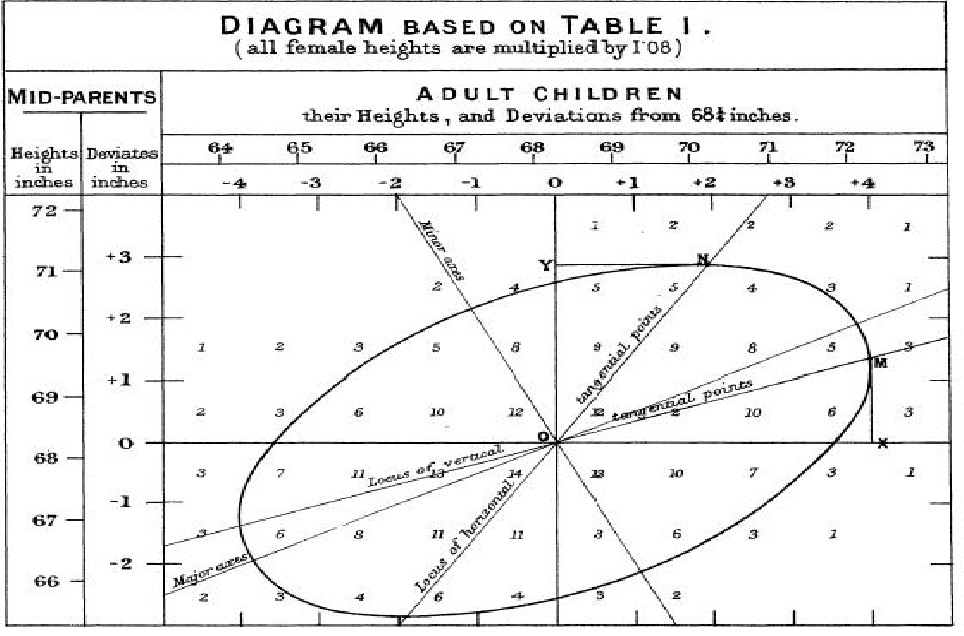

#### Updated Scatterplot #1

Create a scatterplot of child height (x-axis) versus mid-parent height (y-axis). Ordinarily, we might reverse the axes here because analysts would be more likely to model child height as a function of parent height, but we want to be able to compare the updated plot to Galton’s original. Make your dots larger than the default and adjust transparency (`alpha`) to correct for overplotting and help show the density of points.

Also include the following.

- use `color` in the `aes` to differentiate sons versus daughters
- use `scale_color_manual()` to choose two informative colors
- scale both axes so that there is a tick mark at every whole inch
- use `coord_fixed()` so that the axes have the same unit spacing
- add better x- and y-axis labels, including the units of measure
- add an informative title (you may optionally include a subtitle)
- add `color =` to `labs()` to set the legend title to `"gender of child"`
- use `theme_linedraw()` to add some additional plot formatting
- use `theme()` to move the legend to the bottom of the scatterplot

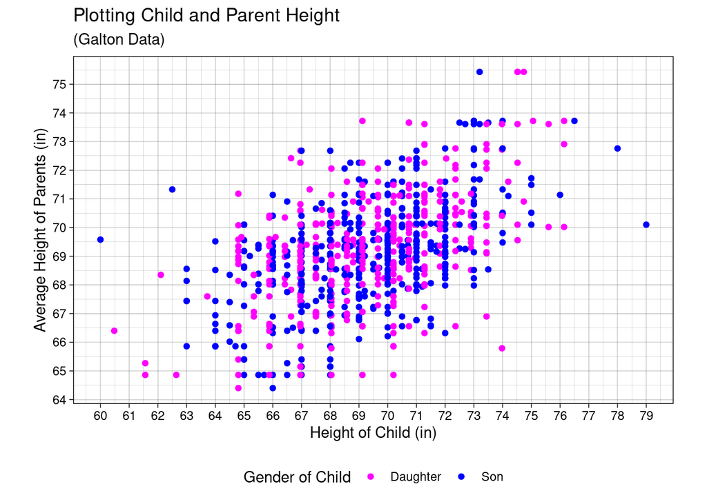

```r
updatedscatterplot1 <- ggplot(assembledata1, aes(child_ht, midparent, color = child_sex)) +
  geom_point() +
  scale_color_manual(values = c("magenta", "blue")) +
  scale_x_continuous(breaks = seq(60, 80, by = 1)) +
  scale_y_continuous(breaks = seq(60, 80, by = 1)) +
  coord_fixed() +
  labs(title = "Plotting Child and Parent Height", subtitle = "(Galton Data)", color = "Gender of Child") +
  xlab("Height of Child (in)") +
  ylab("Average Height of Parents (in)") +
  theme_linedraw() +
  theme(legend.position = "bottom")

updatedscatterplot1
```

#### Updated Scatterplot #2

Remove the color coding for sons versus daughters from your plot, as well as any other coding related to it. Instead, choose n single color for the points and adjust both `size` and transparency (`alpha`) as needed to correct for overplotting and help show the density of points. Reset the `aes` so child height is the `y` variable and midparent height is the `x` variable. Add a fitted *straight* line to the plot. Update your `labs` accordingly.

[figure not shown]

```r
updatedscatterplot2 <- ggplot(assembledata1, aes(midparent, child_ht)) +
  geom_point(color = "blue", alpha = .5, size = 1.5) +
  scale_x_continuous(breaks = seq(60, 80, by = 1)) +
  scale_y_continuous(breaks = seq(60, 80, by = 1)) +
  coord_fixed() +
  labs(title = "Relationship Between Child and Parent Height", subtitle = "(Galton Data)") +
  xlab("Height of Child (in)") +
  ylab("Average Height of Parents (in)") +
  theme_linedraw() +
  geom_smooth(method = "lm", se = FALSE, color = "black")

updatedscatterplot2
```

### Part 2: Number of Children

Create a barplot to show the distribution of the number of children per family. Set the bars to something other than the default `width`. Scale the x-axis so that there is a tick mark for each bar. Choose appropriate colors, labels, themes, and/or and other types of formatting that you feel will enhance the meaning or visual appearance of the plot.

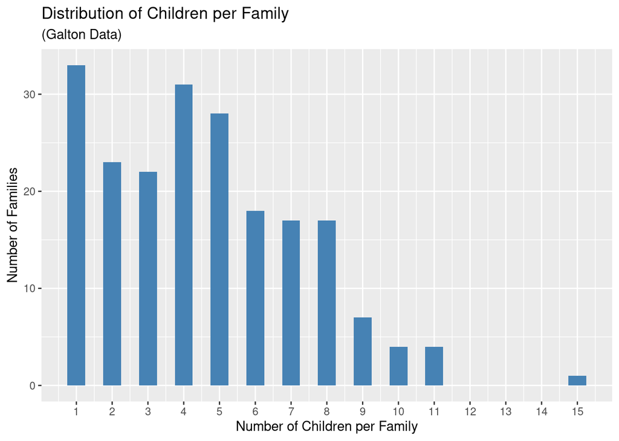

```r
childrenbarplot <- ggplot(assembledata2, aes(num_children)) +
  geom_bar(width = .5, fill = "steelblue") +
  scale_x_continuous(breaks = seq(0, 15, by = 1)) +
  labs(title = "Distribution of Children per Family", subtitle = "(Galton Data)") +
  xlab("Number of Children per Family") +
  ylab("Number of Families")

childrenbarplot
```

## Questions

**Question 1:** Do you think that your scatterplots are an improvement over Galton’s original diagram? Are there any modifications and/or additions you would make to enhance the clarity or usefulness of your plots?

**ANSWER**

I think that my scatter plots are easier to read and come to a conclusion with. If I were to improve these graphs, I’d spend more time picking pleasing colors and make it easier to distinguish individual data point density.

**Question 2:** Explain the rationale behind the choices you made when creating your scatterplots and barplot, such as size, color, transparency, or other features. What motivated your decisions?

**ANSWER**

I mostly stuck to what I was told to do, but tested options like colors, transparency, or size to make graphs that were legible and not too flashy. For example, I tried not to pick colors that meshed with the white background and made sure that my data points were big enough to see alone, and picked titles that were accurate and succinct.

**Question 3:** Considering best practices, how does using `coord_fixed()` enhance the authenticity of the information shown in the scatterplots, such as the relationship and spread of the data?

**ANSWER**

Using ‘coord_fixed()’ to set the x and y axes to equal unit spacing prevents the data from being scaled in a way that could lead to misunderstanding or inaccurate interpretation.